# R Notebook

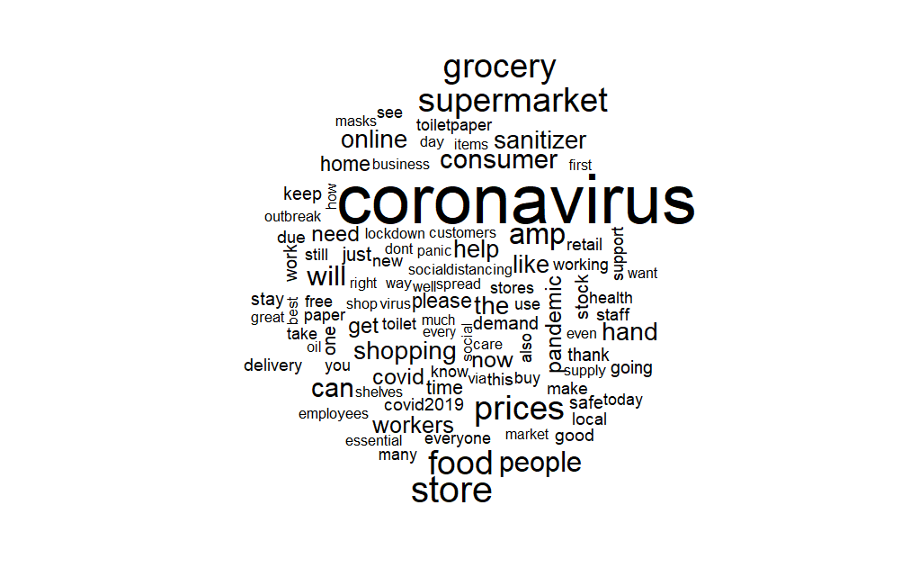

```r
library(wordcloud)
#wordcloud(covid_corpus_clean,  min.freq= 50,  random.order=  FALSE)
positive <-subset(cnt, Sentiment == "Positive")
negative <-subset(cnt, Sentiment == "Negative")
wordcloud(positive$OriginalTweet, max.words= 100, scale = c(3, 0.5))
```

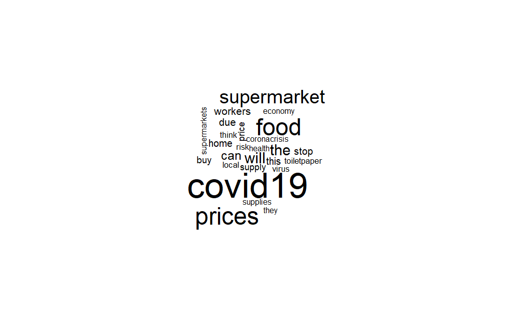

```r
wordcloud(negative$OriginalTweet, max.words= 100, scale = c(3, 0.5))
```

6)a document-term matrix from the cleaned corpus. Then splitting the data into train and test sets.

```r
covid_dtm<-DocumentTermMatrix(covid_corpus_clean)
covid_dtm_train<-covid_dtm[1:32925, ]
covid_dtm_test<-covid_dtm[32926:41157, ]
covid_dtm_train
```

```
<<DocumentTermMatrix (documents: 32925, terms: 86354)>>
Non-/sparse entries: 754712/2842450738
Sparsity           : 100%
Maximal term length: 191
Weighting          : term frequency (tf)
```

```r
covid_dtm_test
```

```
<<DocumentTermMatrix (documents: 8232, terms: 86354)>>
Non-/sparse entries: 187570/710678558
Sparsity           : 100%
Maximal term length: 191
Weighting          : term frequency (tf)
```

```r
covid_train_labels<-cnt[1:32925, ]$Sentiment
covid_test_labels<-cnt[32926:41157, ]$Sentiment
summary(covid_test_labels)
```

```
Positive Negative  neutral
    3576     3059     1597
```

7)Removing the words that appear less than 100 times in the training data. Convert frequencies in the document-term matrix to binary yes/no features

finding frequent words

```r
covid_freq_words<-findFreqTerms(covid_dtm_train,100)
covid_dtm_freq_train<-covid_dtm_train[ , covid_freq_words]
covid_dtm_freq_test<-covid_dtm_test[ , covid_freq_words]
```

```r
convert_counts<-function(x) {
 x <-ifelse(x > 0, "Yes", "No")
}
covid_train<-apply(covid_dtm_freq_train, MARGIN = 2, convert_counts)
covid_test<-apply(covid_dtm_freq_test, MARGIN = 2, convert_counts)
```

8)a Naïve Bayes classifier on the training data and evaluate its performance on the test data.

```r
library(e1071)
covid_classifier<-naiveBayes(covid_train, covid_train_labels)
```

```r
covid_test_pred<-predict(covid_classifier, covid_test)
```

```r
library(gmodels)
CrossTable(covid_test_pred, covid_test_labels, prop.chisq= FALSE, prop.t = FALSE,
dnn= c('predicted', 'actual'))
```

```
   Cell Contents
|-------------------------|
|                       N |
|           N / Row Total |
|           N / Col Total |
|-------------------------|


Total Observations in Table:  8232


             | actual
   predicted |  Positive |  Negative |   neutral | Row Total |
-------------|-----------|-----------|-----------|-----------|
    Positive |      2335 |       628 |       290 |      3253 |
             |     0.718 |     0.193 |     0.089 |     0.395 |
             |     0.653 |     0.205 |     0.182 |           |
-------------|-----------|-----------|-----------|-----------|
    Negative |       646 |      1860 |       248 |      2754 |
             |     0.235 |     0.675 |     0.090 |     0.335 |
             |     0.181 |     0.608 |     0.155 |           |
-------------|-----------|-----------|-----------|-----------|
     neutral |       595 |       571 |      1059 |      2225 |
             |     0.267 |     0.257 |     0.476 |     0.270 |
             |     0.166 |     0.187 |     0.663 |           |
-------------|-----------|-----------|-----------|-----------|
Column Total |      3576 |      3059 |      1597 |      8232 |
             |     0.434 |     0.372 |     0.194 |           |
-------------|-----------|-----------|-----------|-----------|
```

ans: the accuracy of the model is 0.63824101 The accuracy in each category Positive- 2335/3576 - 0.65296421 Negative- 1860/3059 - 0.60804184 neutral- 1059/1597 - 0.66311835.